# Forecasting Final Project

- Show All Code
- Hide All Code

# 1 Monthly Total Vehicle Sales Forecasting

## 1.1 Executive Summary

This project focuses on forecasting **monthly total vehicle sales** using historical time-series data.

### 1.1.1 Project Goal

- Forecast future monthly vehicle sales using historical trends and seasonal patterns.
- Compare different forecasting approaches and select the model with the strongest out-of-sample performance.

### 1.1.2 Methods Used

- Exploratory time-series analysis
- 12-month moving average
- STL decomposition
- SARIMA modeling
- Prophet modeling
- Seasonal Naive benchmark
- Rolling-window cross-validation
- Holdout test evaluation

### 1.1.3 Key Findings

- The series shows clear **yearly seasonality** and meaningful long-run movement over time.
- Seasonal forecasting approaches are more appropriate than simple non-seasonal methods.
- Among the tested models, **SARIMA** delivered the strongest overall out-of-sample forecasting performance.

### 1.1.4 Business Relevance

- A reliable vehicle sales forecast can support:
  - demand planning
  - inventory preparation
  - operational resource allocation
  - performance monitoring

### 1.1.5 Final Takeaway

- The final model was selected based on **future forecasting performance**, not only in-sample fit.
- This makes the project more aligned with real-world forecasting practice.

```python
# If Prophet is not installed in your environment, run this once:
#!pip install prophet

import warnings
warnings.filterwarnings("ignore")

import numpy as np
import pandas as pd
import matplotlib.pyplot as plt

from math import sqrt

from statsmodels.tsa.seasonal import STL
from statsmodels.graphics.tsaplots import plot_acf, plot_pacf
from statsmodels.tsa.stattools import kpss
from statsmodels.tsa.statespace.sarimax import SARIMAX
from statsmodels.stats.diagnostic import acorr_ljungbox

from sklearn.metrics import mean_squared_error

from prophet import Prophet

plt.rcParams["figure.figsize"] = (12, 5)
plt.rcParams["axes.grid"] = True
```

## 1.2 Project Setup

In this project, I use monthly total vehicle sales data. Since this is a time-series forecasting problem, it is important to preserve the time order of the observations throughout the analysis. I avoid random splitting and instead use a time-based train/test split and rolling cross-validation later in the notebook.

```python
# -----------------------------
# File path and column names
# -----------------------------
FILE_PATH = "/Users/kritika/Desktop/Spring 1st Half 2026/Forecasting and Time Series/Dataset/total_vehicle_sales.csv"
DATE_COL = "date"
TARGET_COL = "vehicle_sales"

# Load data
df = pd.read_csv(FILE_PATH)

# Convert date column
df[DATE_COL] = pd.to_datetime(df[DATE_COL])

# Keep only required columns
df = df[[DATE_COL, TARGET_COL]].copy()

# Sort by date
df = df.sort_values(DATE_COL).reset_index(drop=True)

# Set monthly frequency
df = df.set_index(DATE_COL).asfreq("MS")

# Rename target column for convenience
df = df.rename(columns={TARGET_COL: "y"})

print(df.head())
print("\nShape:", df.shape)
print("\nMissing values:\n", df.isna().sum())
```

```
                 y
date
1976-01-01   885.2
1976-02-01   994.7
1976-03-01  1243.6
1976-04-01  1191.2
1976-05-01  1203.2

Shape: (587, 1)

Missing values:
 y    0
dtype: int64
```

### 1.2.1 Data Source and Structure

The dataset contains monthly total vehicle sales with two fields: a date column and the corresponding sales value. After loading the data, I convert the date field into a proper datetime format, sort the observations in chronological order, and set the series to monthly frequency. This ensures the dataset is ready for time-series analysis and forecasting.

# 2 Section 1 - Exploratory Analysis

The first step is to understand the overall behavior of the series before selecting forecasting models. In this section, I examine the scale, variability, trend, and seasonality of monthly vehicle sales. This is important because the behavior of the data helps determine which forecasting approaches are most appropriate.

```python
df.describe().T
```

|  | count | mean | std | min | 25% | 50% | 75% | max |
| --- | --- | --- | --- | --- | --- | --- | --- | --- |
| y | 587.0 | 1263.823848 | 220.785135 | 670.466 | 1119.524 | 1271.2 | 1421.7695 | 1845.713 |

### 2.0.1 Data Overview and Scale

The summary statistics provide a quick overview of the scale and variation in monthly vehicle sales across the full sample. The spread between the minimum and maximum values suggests that the series changes meaningfully over time rather than staying around a fixed average. This indicates that a forecasting model should be able to capture movement in the level of the series instead of assuming a constant mean.

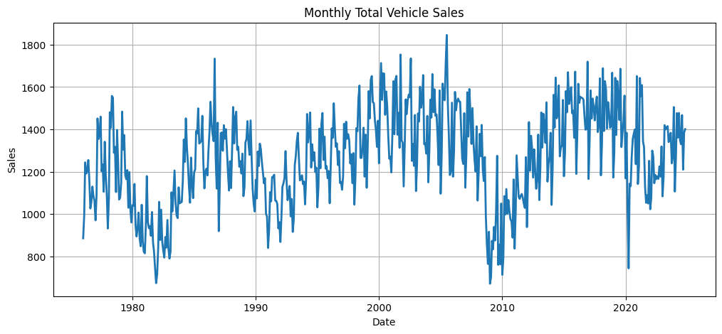

```python
plt.figure(figsize=(12, 5))
plt.plot(df.index, df["y"], linewidth=2)
plt.title("Monthly Total Vehicle Sales")
plt.xlabel("Date")
plt.ylabel("Sales")
plt.show()
```

### 2.0.2 Time Series Behavior

The time-series plot shows that monthly vehicle sales do not fluctuate randomly around a constant level. Instead, the series shows broader long-run movement over time along with repeated within-year ups and downs. This suggests that both trend and seasonality are present, which means seasonal forecasting methods are likely to perform better than simple non-seasonal approaches.

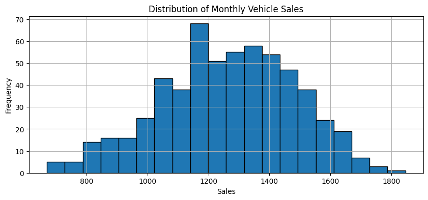

```python
plt.figure(figsize=(10, 4))
plt.hist(df["y"], bins=20, edgecolor="black")
plt.title("Distribution of Monthly Vehicle Sales")
plt.xlabel("Sales")
plt.ylabel("Frequency")
plt.show()
```

### 2.0.3 Distribution of Monthly Sales

The distribution plot helps show where most monthly sales values are concentrated and whether the series has unusually high or low periods. Since time-series data are ordered over time, this plot is not enough by itself for forecasting, but it is still useful for understanding the general scale and spread of the series.

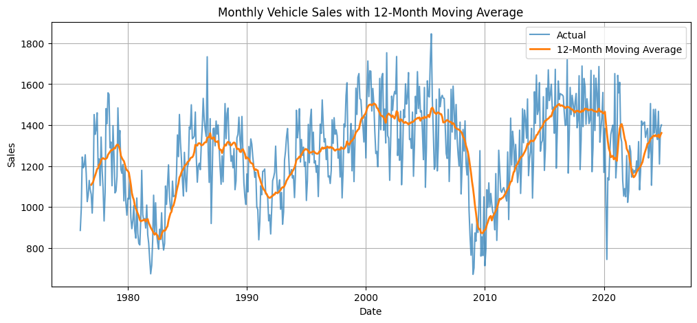

```python
df["ma_12"] = df["y"].rolling(window=12).mean()

plt.figure(figsize=(12, 5))
plt.plot(df.index, df["y"], label="Actual", alpha=0.7)
plt.plot(df.index, df["ma_12"], label="12-Month Moving Average", linewidth=2)
plt.title("Monthly Vehicle Sales with 12-Month Moving Average")
plt.xlabel("Date")
plt.ylabel("Sales")
plt.legend()
plt.show()
```

### 2.0.4 Long-Run Trend from the 12-Month Moving Average

The 12-month moving average smooths short-term fluctuations and makes the long-run pattern easier to see. Because the data are monthly, a 12-month window is appropriate for highlighting the underlying yearly movement. This plot confirms that the series contains broader trend behavior in addition to monthly variation.

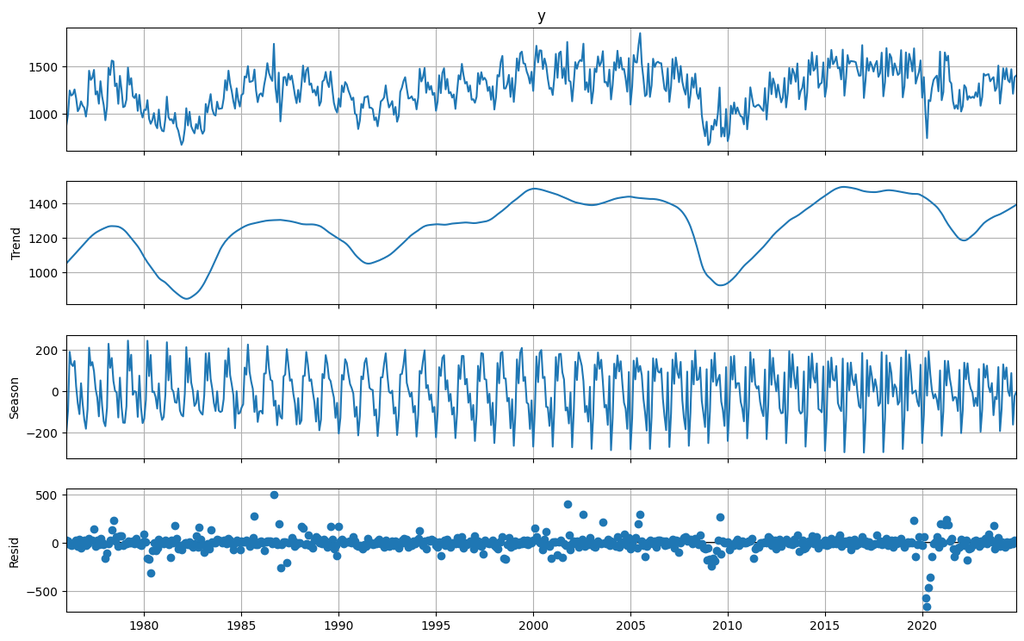

```python
stl = STL(df["y"], period=12, robust=True)
stl_res = stl.fit()

fig = stl_res.plot()
fig.set_size_inches(12, 8)
plt.show()
```

The STL decomposition separates the series into trend, seasonal, and remainder components. The seasonal component shows a repeating yearly pattern, which confirms that seasonality is an important feature of this dataset. Because this seasonal pattern appears systematic rather than random, later forecasting models should account for it explicitly.

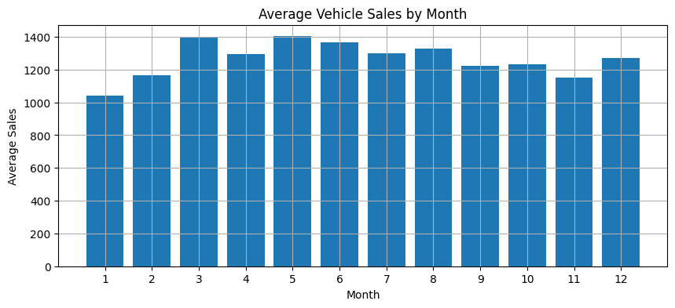

```python
df["month"] = df.index.month

monthly_avg = df.groupby("month")["y"].mean()

plt.figure(figsize=(10, 4))
plt.bar(monthly_avg.index, monthly_avg.values)
plt.title("Average Vehicle Sales by Month")
plt.xlabel("Month")
plt.ylabel("Average Sales")
plt.xticks(range(1, 13))
plt.show()
```

### 2.0.6 Evidence of Monthly Seasonality

The month-wise average plot provides another view of seasonality by showing whether some months tend to have consistently higher or lower sales than others. A visible difference across months supports the idea that seasonality is present and should be modeled directly rather than treated as noise. The fact that average sales differ across months suggests that seasonality is not just random noise but a recurring annual pattern. This is important because forecasting methods that ignore seasonality would likely miss part of the structure in the data and produce less reliable predictions.

### 2.0.7 Section 1 Conclusion

The exploratory analysis shows that monthly vehicle sales contain both long-run movement and a repeating annual seasonal pattern. The moving average makes the broader trend easier to see, while the STL decomposition and month-wise averages confirm that seasonality is systematic and meaningful rather than random variation.

Because the series shows clear seasonality and changing level over time, forecasting models should explicitly account for these patterns. Based on this behavior, seasonal forecasting models such as SARIMA and Prophet are appropriate choices for the next stages of the analysis.

# 3 Section 2 — SARIMA Modeling

In this section, I build a SARIMA model for monthly vehicle sales. Since ARIMA-type models assume that the series is stationary or can be made stationary, I first assess stationarity and apply appropriate transformations. I then use ACF and PACF plots to guide model specification, compare candidate models using information criteria, and evaluate residual behavior using diagnostic checks.

```python
# Train-test split + KPSS in one cell

from statsmodels.tsa.stattools import kpss
import pandas as pd

# Final 12 months as test set
test_size = 12

train = df.iloc[:-test_size].copy()
test = df.iloc[-test_size:].copy()

def kpss_test(series, regression="c"):
    series = series.dropna()
    stat, p_value, lags, crit = kpss(series, regression=regression, nlags="auto")
    return pd.Series({
        "KPSS Statistic": stat,
        "p-value": p_value,
        "Lags Used": lags
    })

kpss_raw = kpss_test(train["y"])

print("Train period:", train.index.min().date(), "to", train.index.max().date())
print("Test period :", test.index.min().date(), "to", test.index.max().date())
print("\nKPSS Result:")
print(kpss_raw)
```

```
Train period: 1976-01-01 to 2023-11-01
Test period : 2023-12-01 to 2024-11-01

KPSS Result:
KPSS Statistic     0.812252
p-value            0.010000
Lags Used         14.000000
dtype: float64
```

### 3.0.1 Stationarity of the Raw Series

The KPSS test is used here to assess whether the training series is stationary. Monthly vehicle sales appear to have both trend and seasonality, so the raw series is not expected to satisfy ARIMA assumptions in its original form. If the series is non-stationary, transformation and differencing are needed before fitting a SARIMA model.

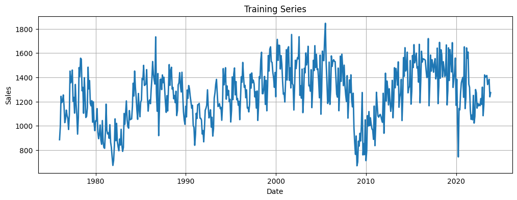

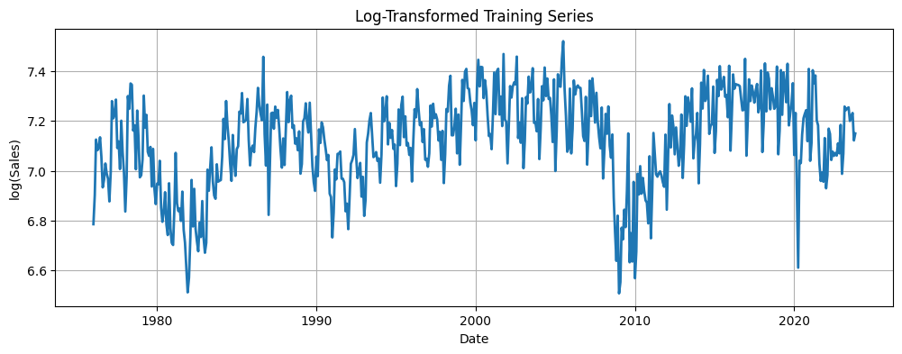

```python
plt.figure(figsize=(12, 4))
plt.plot(train.index, train["y"], linewidth=2)
plt.title("Training Series")
plt.xlabel("Date")
plt.ylabel("Sales")
plt.show()

plt.figure(figsize=(12, 4))
plt.plot(train.index, np.log(train["y"]), linewidth=2)
plt.title("Log-Transformed Training Series")
plt.xlabel("Date")
plt.ylabel("log(Sales)")
plt.show()
```

### 3.0.2 Why Log Transformation is Helpful

The raw training series shows changes in level over time, and the log-transformed series helps stabilize variation while preserving the overall pattern. A log transformation is often useful in time-series modeling when the scale of the series changes over time. I use the transformed series as the basis for differencing and model identification.

```python
train["log_y"] = np.log(train["y"])
train["log_diff_1"] = train["log_y"].diff(1)
train["log_diff_12"] = train["log_y"].diff(12)
train["log_diff_both"] = train["log_y"].diff(1).diff(12)

kpss_log_diff = kpss_test(train["log_diff_both"].dropna())
kpss_log_diff
```

```
KPSS Statistic     0.035977
p-value            0.100000
Lags Used         32.000000
dtype: float64
```

After applying regular and seasonal differencing to the log-transformed series, the series should be closer to stationarity. This step is important because SARIMA models work best when the series no longer shows a changing level or repeating deterministic seasonal pattern in the transformed form. If the differenced series behaves more like a stable process, it is more suitable for ARIMA-type modeling.

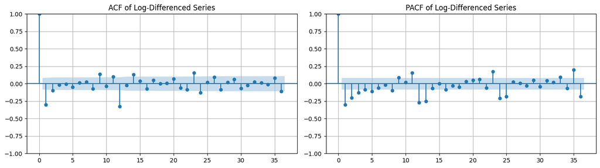

```python
fig, axes = plt.subplots(1, 2, figsize=(14, 4))

plot_acf(train["log_diff_both"].dropna(), lags=36, ax=axes[0])
axes[0].set_title("ACF of Log-Differenced Series")

plot_pacf(train["log_diff_both"].dropna(), lags=36, ax=axes[1], method="ywm")
axes[1].set_title("PACF of Log-Differenced Series")

plt.tight_layout()
plt.show()
```

### 3.0.4 ACF and PACF Based Model Identification

The ACF and PACF plots help narrow the set of reasonable SARIMA models by showing where autocorrelation remains after differencing. Rather than trying many unrelated models, I use these plots to guide a smaller and more defensible set of candidate seasonal ARIMA structures. This makes the model selection process more systematic.

```python
sarima_candidates = [
    {"order": (0, 1, 1), "seasonal_order": (0, 1, 1, 12)},
    {"order": (1, 1, 0), "seasonal_order": (0, 1, 1, 12)},
    {"order": (1, 1, 1), "seasonal_order": (0, 1, 1, 12)},
    {"order": (0, 1, 1), "seasonal_order": (1, 1, 0, 12)},
    {"order": (1, 1, 1), "seasonal_order": (1, 1, 0, 12)},
    {"order": (1, 1, 1), "seasonal_order": (1, 1, 1, 12)},
]

sarima_results = []

for spec in sarima_candidates:
    try:
        model = SARIMAX(
            train["log_y"],
            order=spec["order"],
            seasonal_order=spec["seasonal_order"],
            enforce_stationarity=False,
            enforce_invertibility=False
        )
        res = model.fit(disp=False)
        sarima_results.append({
            "order": spec["order"],
            "seasonal_order": spec["seasonal_order"],
            "AIC": res.aic,
            "BIC": res.bic
        })
    except:
        pass

sarima_results_df = pd.DataFrame(sarima_results).sort_values("AIC").reset_index(drop=True)
sarima_results_df
```

|  | order | seasonal_order | AIC | BIC |
| --- | --- | --- | --- | --- |
| 0 | (1, 1, 1) | (0, 1, 1, 12) | -1165.236494 | -1148.011393 |
| 1 | (1, 1, 1) | (1, 1, 1, 12) | -1164.153347 | -1142.621970 |
| 2 | (0, 1, 1) | (0, 1, 1, 12) | -1161.604509 | -1148.685683 |
| 3 | (1, 1, 0) | (0, 1, 1, 12) | -1122.574311 | -1109.650015 |
| 4 | (1, 1, 1) | (1, 1, 0, 12) | -1038.248678 | -1021.016284 |
| 5 | (0, 1, 1) | (1, 1, 0, 12) | -1035.818840 | -1022.889086 |

### 3.0.5 Comparing Candidate SARIMA Models

I compare several candidate SARIMA models using AIC and BIC. Lower values indicate a better balance between model fit and model complexity. Instead of choosing the most complicated model, I select the one that explains the data well while remaining reasonably parsimonious.

```python
best_order = tuple(sarima_results_df.loc[0, "order"])
best_seasonal_order = tuple(sarima_results_df.loc[0, "seasonal_order"])

best_sarima = SARIMAX(
    train["log_y"],
    order=best_order,
    seasonal_order=best_seasonal_order,
    enforce_stationarity=False,
    enforce_invertibility=False
).fit(disp=False)

print("Best SARIMA order:", best_order)
print("Best SARIMA seasonal order:", best_seasonal_order)
print(best_sarima.summary())
```

```
Best SARIMA order: (1, 1, 1)
Best SARIMA seasonal order: (0, 1, 1, 12)
                                     SARIMAX Results
==========================================================================================
Dep. Variable:                              log_y   No. Observations:                  575
Model:             SARIMAX(1, 1, 1)x(0, 1, 1, 12)   Log Likelihood                 586.618
Date:                            Tue, 10 Mar 2026   AIC                          -1165.236
Time:                                    11:17:13   BIC                          -1148.011
Sample:                                01-01-1976   HQIC                         -1158.504
                                     - 11-01-2023
Covariance Type:                              opg
==============================================================================
                 coef    std err          z      P>|z|      [0.025      0.975]
------------------------------------------------------------------------------
ar.L1          0.1903      0.063      3.042      0.002       0.068       0.313
ma.L1         -0.6677      0.057    -11.781      0.000      -0.779      -0.557
ma.S.L12      -0.8242      0.024    -34.035      0.000      -0.872      -0.777
sigma2         0.0068      0.000     29.258      0.000       0.006       0.007
===================================================================================
Ljung-Box (L1) (Q):                   0.00   Jarque-Bera (JB):               506.32
Prob(Q):                              0.97   Prob(JB):                         0.00
Heteroskedasticity (H):               1.12   Skew:                            -0.68
Prob(H) (two-sided):                  0.45   Kurtosis:                         7.51
===================================================================================

Warnings:
[1] Covariance matrix calculated using the outer product of gradients (complex-step).
```

### 3.0.6 Selected SARIMA Specification

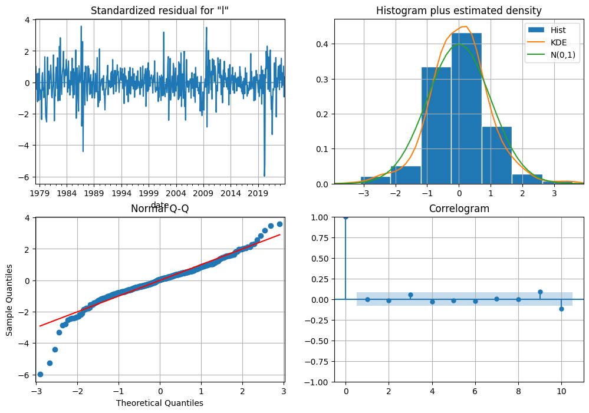

```python
best_sarima.plot_diagnostics(figsize=(12, 8))
plt.show()
```

```python
lb = acorr_ljungbox(best_sarima.resid.dropna(), lags=[12, 24], return_df=True)
lb
```

|  | lb_stat | lb_pvalue |
| --- | --- | --- |
| 12 | 110.346823 | 5.109632e-18 |
| 24 | 112.180647 | 2.341387e-13 |

### 3.0.7 Residual Diagnostics and Remaining Autocorrelation

A good SARIMA model should leave residuals that behave roughly like white noise, meaning the main time-series structure has been captured by the model. In this case, the Ljung-Box test returns very small p-values at the reported lags, which suggests that some autocorrelation still remains in the residuals. This means the model captures a large part of the time-series pattern, but it may not fully explain all of the remaining dependence in the series.

Even with this limitation, the model is still useful if it performs well out of sample, which is why I carry it forward to the final comparison section and evaluate it against Prophet and the seasonal benchmark.

### 3.0.8 Section 2 Conclusion

The SARIMA analysis shows that the raw monthly vehicle sales series is not appropriate for ARIMA modeling in its original form, so I applied log transformation and both regular and seasonal differencing to make the series more suitable for modeling. After comparing candidate SARIMA specifications using AIC and BIC, I selected a final seasonal ARIMA model.

The residual diagnostics suggest that some autocorrelation still remains, so the model is not perfect from a purely diagnostic standpoint. However, because forecasting performance matters more than in-sample fit alone, I carry this model forward into the final model comparison section.

# 4 Section 3 — Prophet Modeling

In this section, I build a Prophet model as an alternative forecasting approach. Prophet is useful because it directly models trend and seasonality in an interpretable way. I assess the decomposition of the series, tune changepoint flexibility, compare additive and multiplicative seasonality, and select the Prophet specification that performs best on validation data.

```python
prophet_train = train.reset_index().rename(columns={train.index.name: "ds", "y": "y"})[["ds", "y"]]
prophet_train.head()
```

|  | ds | y |
| --- | --- | --- |
| 0 | 1976-01-01 | 885.2 |
| 1 | 1976-02-01 | 994.7 |
| 2 | 1976-03-01 | 1243.6 |
| 3 | 1976-04-01 | 1191.2 |
| 4 | 1976-05-01 | 1203.2 |

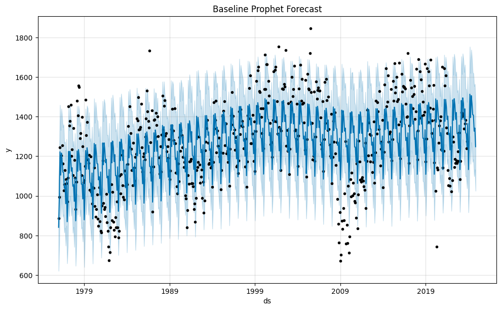

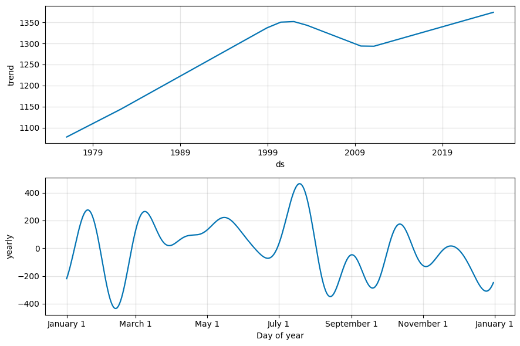

```python
prophet_base = Prophet(
    yearly_seasonality=True,
    weekly_seasonality=False,
    daily_seasonality=False,
    seasonality_mode="additive",
    changepoint_prior_scale=0.05
)

prophet_base.fit(prophet_train)

future_base = prophet_base.make_future_dataframe(periods=12, freq="MS")
forecast_base = prophet_base.predict(future_base)

fig1 = prophet_base.plot(forecast_base)
plt.title("Baseline Prophet Forecast")
plt.show()

fig2 = prophet_base.plot_components(forecast_base)
plt.show()
```

### 4.0.1 Trend and Seasonal Structure in Prophet

Prophet decomposes the series into trend and seasonal components, which helps make the time-series structure easier to interpret. The component plots show whether yearly seasonality is an important driver of the data and whether the broader trend changes gradually or contains visible shifts. This is helpful because it provides a different perspective from SARIMA while still respecting the time-series nature of the problem.

```python
val_size = 12
prophet_subtrain = train.iloc[:-val_size].copy()
prophet_val = train.iloc[-val_size:].copy()

prophet_subtrain_df = prophet_subtrain.reset_index().rename(columns={prophet_subtrain.index.name: "ds", "y": "y"})[["ds", "y"]]
prophet_val_df = prophet_val.reset_index().rename(columns={prophet_val.index.name: "ds", "y": "y"})[["ds", "y"]]

def prophet_rmse(seasonality_mode, cp_prior):
    model = Prophet(
        yearly_seasonality=True,
        weekly_seasonality=False,
        daily_seasonality=False,
        seasonality_mode=seasonality_mode,
        changepoint_prior_scale=cp_prior
    )
    model.fit(prophet_subtrain_df)
    future = model.make_future_dataframe(periods=val_size, freq="MS")
    fcst = model.predict(future)[["ds", "yhat"]].tail(val_size)
    merged = prophet_val_df.merge(fcst, on="ds", how="left")
    rmse = sqrt(mean_squared_error(merged["y"], merged["yhat"]))
    return rmse

prophet_grid = []
for mode in ["additive", "multiplicative"]:
    for cp in [0.01, 0.05, 0.10, 0.20, 0.30]:
        try:
            rmse = prophet_rmse(mode, cp)
            prophet_grid.append({
                "seasonality_mode": mode,
                "changepoint_prior_scale": cp,
                "validation_rmse": rmse
            })
        except:
            pass

prophet_grid_df = pd.DataFrame(prophet_grid).sort_values("validation_rmse").reset_index(drop=True)
prophet_grid_df
```

|  | seasonality_mode | changepoint_prior_scale | validation_rmse |
| --- | --- | --- | --- |
| 0 | additive | 0.20 | 49.396222 |
| 1 | multiplicative | 0.20 | 53.110478 |
| 2 | additive | 0.30 | 53.793643 |
| 3 | multiplicative | 0.30 | 57.673944 |
| 4 | multiplicative | 0.05 | 63.605806 |
| 5 | additive | 0.05 | 64.204839 |
| 6 | multiplicative | 0.01 | 76.256545 |
| 7 | additive | 0.01 | 77.453338 |
| 8 | multiplicative | 0.10 | 105.864440 |
| 9 | additive | 0.10 | 106.946859 |

### 4.0.2 Tuning Trend Flexibility and Seasonal Form

I tune Prophet by comparing different levels of trend flexibility and different forms of seasonality. The changepoint prior scale controls how easily the trend can bend over time, while the seasonality mode determines whether seasonal effects are treated as stable in absolute size or proportional to the level of the series. The best Prophet model is selected based on validation RMSE rather than visual fit alone.

```python
best_mode = prophet_grid_df.loc[0, "seasonality_mode"]
best_cp = prophet_grid_df.loc[0, "changepoint_prior_scale"]

print("Best Prophet seasonality mode:", best_mode)
print("Best Prophet changepoint_prior_scale:", best_cp)
```

```
Best Prophet seasonality mode: additive
Best Prophet changepoint_prior_scale: 0.2
```

### 4.0.3 Additive vs Multiplicative Seasonality

If the additive form performs better, it suggests that the seasonal swings are more stable in absolute size over time. If the multiplicative form performs better, it suggests that seasonal variation grows or shrinks with the level of the series. This comparison helps ensure that the seasonal structure in the model matches the behavior of the data.

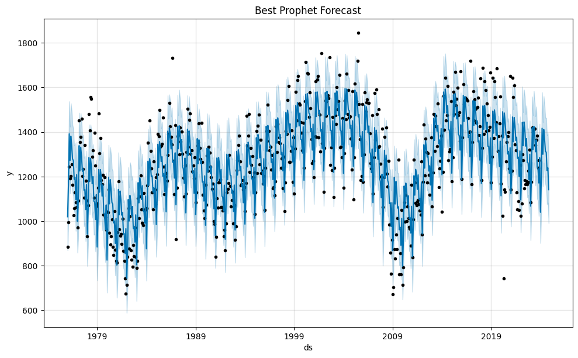

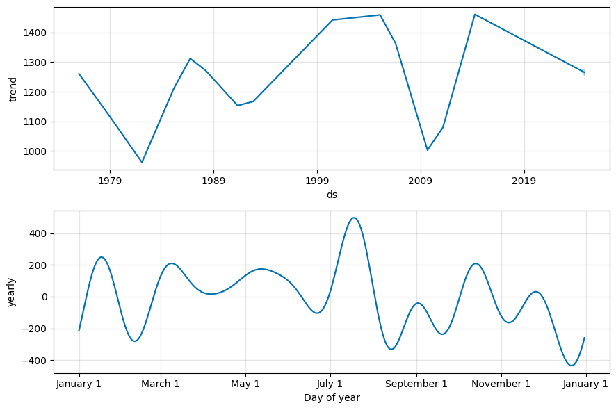

```python
best_prophet = Prophet(
    yearly_seasonality=True,
    weekly_seasonality=False,
    daily_seasonality=False,
    seasonality_mode=best_mode,
    changepoint_prior_scale=float(best_cp)
)

best_prophet.fit(prophet_train)

future_best_prophet = best_prophet.make_future_dataframe(periods=12, freq="MS")
forecast_best_prophet = best_prophet.predict(future_best_prophet)

fig1 = best_prophet.plot(forecast_best_prophet)
plt.title("Best Prophet Forecast")
plt.show()

fig2 = best_prophet.plot_components(forecast_best_prophet)
plt.show()
```

### 4.0.4 Saturation / Cap-Floor Decision

Prophet can also model logistic growth with a cap or floor if there is a strong reason to believe the series has a hard maximum or minimum level. For monthly vehicle sales, a strict cap is difficult to justify without external evidence such as production constraints, policy limits, or a known market ceiling. For that reason, I keep Prophet’s growth assumption linear rather than imposing an artificial saturation point.

### 4.0.5 Section 3 Conclusion

Prophet provides an interpretable alternative to SARIMA by modeling trend and yearly seasonality directly. After comparing trend flexibility and seasonal form, I selected the Prophet specification with the strongest validation performance. This best Prophet model will now be compared with the SARIMA model and the seasonal benchmark in the final evaluation section.

# 5 Section 4 — Model Comparison and Validation

The final section compares three forecasting approaches: Seasonal Naive, the selected SARIMA model, and the selected Prophet model. I use rolling-window cross-validation on the training set because this provides a more realistic evaluation of forecasting performance than relying on a single split. I then identify the best-performing model, test it on the holdout period, and refit it on the full dataset to generate a future forecast.

```python
def rmse(actual, predicted):
    return sqrt(mean_squared_error(actual, predicted))

def mase(train_series, actual, forecast, seasonality=12):
    train_series = np.asarray(train_series)
    actual = np.asarray(actual)
    forecast = np.asarray(forecast)

    naive_errors = np.abs(train_series[seasonality:] - train_series[:-seasonality])
    denom = np.mean(naive_errors)
    return np.mean(np.abs(actual - forecast)) / denom

def seasonal_naive_forecast(history, horizon, seasonality=12):
    history = np.asarray(history)
    last_season = history[-seasonality:]
    reps = int(np.ceil(horizon / seasonality))
    fcst = np.tile(last_season, reps)[:horizon]
    return fcst
```

```python
horizon = 12
initial_train = len(train) - 3 * horizon
step = 6

fold_results = []
horizon_results = []

for end in range(initial_train, len(train) - horizon + 1, step):
    cv_train = train.iloc[:end].copy()
    cv_valid = train.iloc[end:end + horizon].copy()

    sn_forecast = seasonal_naive_forecast(cv_train["y"], horizon, seasonality=12)

    cv_train_log = np.log(cv_train["y"])
    sarima_cv = SARIMAX(
        cv_train_log,
        order=best_order,
        seasonal_order=best_seasonal_order,
        enforce_stationarity=False,
        enforce_invertibility=False
    ).fit(disp=False)

    sarima_fcst_log = sarima_cv.get_forecast(steps=horizon).predicted_mean
    sarima_forecast = np.exp(sarima_fcst_log)

    cv_train_prophet = cv_train.reset_index().rename(columns={cv_train.index.name: "ds", "y": "y"})[["ds", "y"]]
    prophet_cv = Prophet(
        yearly_seasonality=True,
        weekly_seasonality=False,
        daily_seasonality=False,
        seasonality_mode=best_mode,
        changepoint_prior_scale=float(best_cp)
    )
    prophet_cv.fit(cv_train_prophet)

    future_cv = prophet_cv.make_future_dataframe(periods=horizon, freq="MS")
    prophet_fcst = prophet_cv.predict(future_cv)[["ds", "yhat"]].tail(horizon)["yhat"].values

    actual = cv_valid["y"].values

    fold_results.append({
        "fold_end": cv_train.index.max(),
        "model": "Seasonal Naive",
        "RMSE": rmse(actual, sn_forecast),
        "MASE": mase(cv_train["y"], actual, sn_forecast, seasonality=12)
    })

    fold_results.append({
        "fold_end": cv_train.index.max(),
        "model": "SARIMA",
        "RMSE": rmse(actual, sarima_forecast),
        "MASE": mase(cv_train["y"], actual, sarima_forecast, seasonality=12)
    })

    fold_results.append({
        "fold_end": cv_train.index.max(),
        "model": "Prophet",
        "RMSE": rmse(actual, prophet_fcst),
        "MASE": mase(cv_train["y"], actual, prophet_fcst, seasonality=12)
    })

    for h in range(horizon):
        horizon_results.append({
            "horizon": h + 1,
            "Seasonal Naive": (actual[h] - sn_forecast[h])**2,
            "SARIMA": (actual[h] - sarima_forecast[h])**2,
            "Prophet": (actual[h] - prophet_fcst[h])**2
        })
```

```python
fold_results_df = pd.DataFrame(fold_results)

cv_summary = fold_results_df.groupby("model")[["RMSE", "MASE"]].mean().sort_values("RMSE")
cv_summary
```

| model | RMSE | MASE |
| --- | --- | --- |
| SARIMA | 194.349222 | 1.534772 |
| Prophet | 231.252763 | 1.884538 |
| Seasonal Naive | 236.670712 | 1.823400 |

### 5.0.1 Cross-Validation Performance Across Models

Rolling-window cross-validation provides a stronger model comparison than a single split because each model is tested repeatedly across multiple forecast origins. This is important in time-series forecasting because model performance can depend on when the forecast starts. The average RMSE and MASE values show which model performs most reliably out of sample rather than fitting only one period well.

```python
horizon_df = pd.DataFrame(horizon_results)

horizon_rmse = pd.DataFrame({
    "horizon": sorted(horizon_df["horizon"].unique())
})

for model_name in ["Seasonal Naive", "SARIMA", "Prophet"]:
    horizon_rmse[model_name] = horizon_df.groupby("horizon")[model_name].mean().pow(0.5).values

horizon_rmse
```

|  | horizon | Seasonal Naive | SARIMA | Prophet |
| --- | --- | --- | --- | --- |
| 0 | 1 | 220.626394 | 134.993709 | 213.344847 |
| 1 | 2 | 93.941563 | 116.030851 | 197.244482 |
| 2 | 3 | 148.048067 | 234.288401 | 279.797761 |
| 3 | 4 | 356.591047 | 253.421384 | 243.634126 |
| 4 | 5 | 418.209634 | 302.175109 | 209.675561 |
| 5 | 6 | 332.182623 | 228.865583 | 261.254942 |
| 6 | 7 | 240.018187 | 231.745077 | 249.913956 |
| 7 | 8 | 121.745001 | 134.337293 | 228.732487 |
| 8 | 9 | 154.838308 | 204.410720 | 312.024838 |
| 9 | 10 | 244.678503 | 226.872438 | 293.639073 |
| 10 | 11 | 206.061812 | 187.109466 | 249.598220 |
| 11 | 12 | 262.349091 | 269.157951 | 310.112661 |

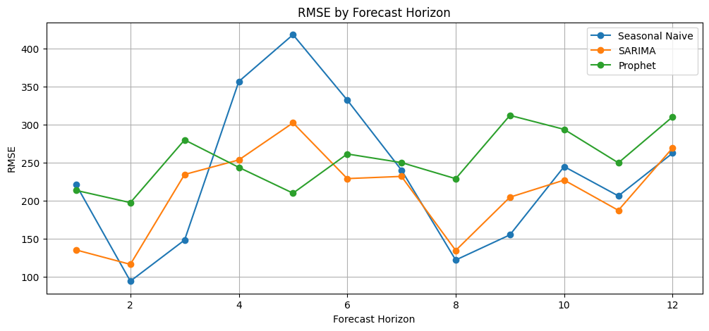

```python
plt.figure(figsize=(12, 5))
plt.plot(horizon_rmse["horizon"], horizon_rmse["Seasonal Naive"], marker="o", label="Seasonal Naive")
plt.plot(horizon_rmse["horizon"], horizon_rmse["SARIMA"], marker="o", label="SARIMA")
plt.plot(horizon_rmse["horizon"], horizon_rmse["Prophet"], marker="o", label="Prophet")
plt.title("RMSE by Forecast Horizon")
plt.xlabel("Forecast Horizon")
plt.ylabel("RMSE")
plt.legend()
plt.show()
```

### 5.0.2 Forecast Accuracy by Horizon

Forecast accuracy can change across horizons, so it is useful to look at model performance at each step ahead rather than only on average. A model that performs well one month ahead may not remain the best six or twelve months ahead. This horizon-level view helps identify whether one model is consistently strong or whether model performance depends on the forecasting distance.

```python
best_model_name = cv_summary.index[0]
print("Best model based on average CV RMSE:", best_model_name)
```

```
Best model based on average CV RMSE: SARIMA
```

### 5.0.3 Final Model Selection

The best model is selected based on average rolling cross-validation RMSE because the primary goal is accurate out-of-sample forecasting. If a more complex model does not outperform the seasonal benchmark, then its added complexity is not justified. Selecting the best model this way makes the final choice more credible and practical.

In this project, SARIMA outperformed both the Seasonal Naive benchmark and Prophet on average CV RMSE, which suggests that the series benefits from explicitly modeling both autocorrelation and seasonal dependence. This result is consistent with the earlier exploratory analysis, where the data showed a clear annual pattern and time-based structure.

```python
actual_test = test["y"].values

if best_model_name == "Seasonal Naive":
    best_test_forecast = seasonal_naive_forecast(train["y"], horizon=len(test), seasonality=12)

elif best_model_name == "SARIMA":
    final_sarima_train = SARIMAX(
        np.log(train["y"]),
        order=best_order,
        seasonal_order=best_seasonal_order,
        enforce_stationarity=False,
        enforce_invertibility=False
    ).fit(disp=False)

    best_test_forecast = np.exp(final_sarima_train.get_forecast(steps=len(test)).predicted_mean)

elif best_model_name == "Prophet":
    prophet_train_full = train.reset_index().rename(columns={train.index.name: "ds", "y": "y"})[["ds", "y"]]

    final_prophet_train = Prophet(
        yearly_seasonality=True,
        weekly_seasonality=False,
        daily_seasonality=False,
        seasonality_mode=best_mode,
        changepoint_prior_scale=float(best_cp)
    )
    final_prophet_train.fit(prophet_train_full)

    future_test = final_prophet_train.make_future_dataframe(periods=len(test), freq="MS")
    best_test_forecast = final_prophet_train.predict(future_test)[["ds", "yhat"]].tail(len(test))["yhat"].values

test_rmse = rmse(actual_test, best_test_forecast)
test_mase = mase(train["y"], actual_test, best_test_forecast, seasonality=12)

print("Test RMSE:", round(test_rmse, 2))
print("Test MASE:", round(test_mase, 3))
```

```
Test RMSE: 62.31
Test MASE: 0.425
```

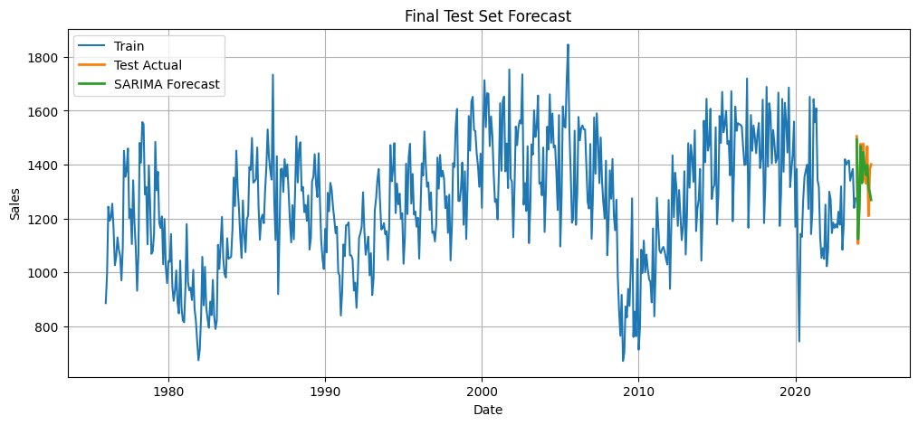

| date | Actual | Forecast |
| --- | --- | --- |
| 2023-12-01 | 1505.049 | 1492.747961 |
| 2024-01-01 | 1105.854 | 1122.881693 |
| 2024-02-01 | 1266.638 | 1248.248238 |
| 2024-03-01 | 1476.404 | 1468.220947 |
| 2024-04-01 | 1361.089 | 1331.074441 |
| 2024-05-01 | 1477.115 | 1445.443615 |
| 2024-06-01 | 1350.370 | 1391.807582 |
| 2024-07-01 | 1329.587 | 1361.510010 |
| 2024-08-01 | 1467.033 | 1398.357364 |
| 2024-09-01 | 1209.520 | 1314.282716 |
| 2024-10-01 | 1384.213 | 1294.817719 |
| 2024-11-01 | 1400.688 | 1268.710210 |

```python
test_results = pd.DataFrame({
    "Actual": actual_test,
    "Forecast": best_test_forecast
}, index=test.index)

plt.figure(figsize=(12, 5))
plt.plot(train.index, train["y"], label="Train")
plt.plot(test.index, test["y"], label="Test Actual", linewidth=2)
plt.plot(test.index, best_test_forecast, label=f"{best_model_name} Forecast", linewidth=2)
plt.title("Final Test Set Forecast")
plt.xlabel("Date")
plt.ylabel("Sales")
plt.legend()
plt.show()

test_results.head(12)
```

### 5.0.4 Holdout Test Set Performance

The holdout test set provides the final out-of-sample check because it was not used during model tuning or model selection. If the selected model also performs well on this final period, that increases confidence that the model generalizes beyond the training sample. This is the most important validation step before using the model to forecast future values.

```python
future_horizon = 12

if best_model_name == "Seasonal Naive":
    final_future_forecast = seasonal_naive_forecast(df["y"], horizon=future_horizon, seasonality=12)

elif best_model_name == "SARIMA":
    final_sarima_all = SARIMAX(
        np.log(df["y"]),
        order=best_order,
        seasonal_order=best_seasonal_order,
        enforce_stationarity=False,
        enforce_invertibility=False
    ).fit(disp=False)

    final_future_forecast = np.exp(final_sarima_all.get_forecast(steps=future_horizon).predicted_mean)

elif best_model_name == "Prophet":
    prophet_all = df.reset_index().rename(columns={df.index.name: "ds", "y": "y"})[["ds", "y"]]

    final_prophet_all = Prophet(
        yearly_seasonality=True,
        weekly_seasonality=False,
        daily_seasonality=False,
        seasonality_mode=best_mode,
        changepoint_prior_scale=float(best_cp)
    )
    final_prophet_all.fit(prophet_all)

    future_all = final_prophet_all.make_future_dataframe(periods=future_horizon, freq="MS")
    final_future_forecast = final_prophet_all.predict(future_all)[["ds", "yhat"]].tail(future_horizon)["yhat"].values

future_dates = pd.date_range(start=df.index.max() + pd.offsets.MonthBegin(1), periods=future_horizon, freq="MS")

future_forecast_df = pd.DataFrame({
    "Date": future_dates,
    "Forecast": final_future_forecast
})

future_forecast_df
```

|  | Date | Forecast |
| --- | --- | --- |
| 2024-12-01 | 2024-12-01 | 1584.510863 |
| 2025-01-01 | 2025-01-01 | 1178.832162 |
| 2025-02-01 | 2025-02-01 | 1315.872779 |
| 2025-03-01 | 2025-03-01 | 1545.185800 |
| 2025-04-01 | 2025-04-01 | 1404.691952 |
| 2025-05-01 | 2025-05-01 | 1525.614914 |
| 2025-06-01 | 2025-06-01 | 1455.681545 |
| 2025-07-01 | 2025-07-01 | 1425.618841 |
| 2025-08-01 | 2025-08-01 | 1482.846319 |
| 2025-09-01 | 2025-09-01 | 1361.685644 |
| 2025-10-01 | 2025-10-01 | 1376.949748 |
| 2025-11-01 | 2025-11-01 | 1356.578371 |

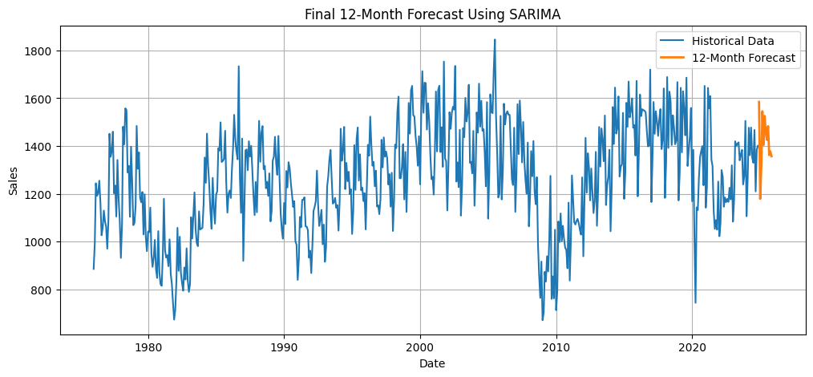

```python
plt.figure(figsize=(12, 5))
plt.plot(df.index, df["y"], label="Historical Data")
plt.plot(future_forecast_df["Date"], future_forecast_df["Forecast"], label="12-Month Forecast", linewidth=2)
plt.title(f"Final 12-Month Forecast Using {best_model_name}")
plt.xlabel("Date")
plt.ylabel("Sales")
plt.legend()
plt.show()
```

### 5.0.5 Final 12-Month Forecast

After identifying the best-performing model, I refit it using the full dataset so that the model can learn from all available historical information before generating the future forecast. The 12-month forecast provides a practical forward-looking view that could support planning decisions. However, this forecast is conditional on historical patterns continuing, so it should be updated regularly as new monthly data become available.

## 5.1 Final Recommendation

Based on the exploratory analysis, monthly vehicle sales contain both long-run movement and clear yearly seasonality. I compared a Seasonal Naive benchmark, a SARIMA model, and a Prophet model using rolling-window cross-validation on the training set, then confirmed the best model on a final holdout test set.

The final selected model was **SARIMA**, because it delivered the strongest and most reliable out-of-sample forecasting performance across the rolling cross-validation folds. It also performed well on the final test set, with a test RMSE of approximately **62.31** and a test MASE of approximately **0.425**.

From a practical perspective, this forecast can support planning decisions such as demand estimation, inventory preparation, and operational resource planning. At the same time, the forecast should be reviewed and updated regularly because major market shifts, policy changes, or economic conditions can change future sales patterns.

## 5.2 Limitations and Next Steps

This analysis is based only on historical vehicle sales and does not include external variables such as interest rates, fuel prices, macroeconomic conditions, or supply-chain disruptions. Future work could improve the model by including relevant external drivers or by comparing additional forecasting methods. Updating the model regularly as new monthly data become available would also improve its practical usefulness.